# Project 2: Movie Lens Case Study

### Step1 : Read the dataets and load them into Dataframes

```python
# importing required libraries for processings
import pandas as pd
import numpy as np
import matplotlib.pyplot as plt
%matplotlib inline
import seaborn as sns
import warnings
warnings.filterwarnings("ignore")
```

```python
# Read the movies.dat file and assign the column names
MoviesDF = pd.read_csv("C:/Users/E056362/Documents/1 New Project/Datasets/Movie Lens/movies.dat",sep="::",
                      header=None)
```

```python
MoviesDF.columns = ['MovieID','Title','Genres']
```

```python
MoviesDF.head()
```

|  | MovieID | Title | Genres |
| --- | --- | --- | --- |
| 0 | 1 | Toy Story (1995) | Animation\|Children's\|Comedy |
| 1 | 2 | Jumanji (1995) | Adventure\|Children's\|Fantasy |
| 2 | 3 | Grumpier Old Men (1995) | Comedy\|Romance |
| 3 | 4 | Waiting to Exhale (1995) | Comedy\|Drama |
| 4 | 5 | Father of the Bride Part II (1995) | Comedy |

```python
# Let us check weather the Movies Data has Missing values in it
MoviesDF.info()
```

```
<class 'pandas.core.frame.DataFrame'>
RangeIndex: 3883 entries, 0 to 3882
Data columns (total 3 columns):
MovieID    3883 non-null int64
Title      3883 non-null object
Genres     3883 non-null object
dtypes: int64(1), object(2)
memory usage: 91.1+ KB
```

```python
# Read the ratings.dat file and assign the columns names
RatingsDF = pd.read_csv("C:/Users/E056362/Documents/1 New Project/Datasets/Movie Lens/ratings.dat",sep="::",
                      header=None)
```

```python
RatingsDF.columns = ['UserID','MovieID','Rating','Timestamp']
```

```python
RatingsDF.head()
```

|  | UserID | MovieID | Rating | Timestamp |
| --- | --- | --- | --- | --- |
| 0 | 1 | 1193 | 5 | 978300760 |
| 1 | 1 | 661 | 3 | 978302109 |
| 2 | 1 | 914 | 3 | 978301968 |
| 3 | 1 | 3408 | 4 | 978300275 |
| 4 | 1 | 2355 | 5 | 978824291 |

```python
# Let us check if the Ratings Dataset has missing values in it
print(RatingsDF.info())
print("-----------------------------------------------------------------------")
print(RatingsDF.isnull().any())
```

```
<class 'pandas.core.frame.DataFrame'>
RangeIndex: 1000209 entries, 0 to 1000208
Data columns (total 4 columns):
UserID       1000209 non-null int64
MovieID      1000209 non-null int64
Rating       1000209 non-null int64
Timestamp    1000209 non-null int64
dtypes: int64(4)
memory usage: 30.5 MB
None
-----------------------------------------------------------------------
UserID       False
MovieID      False
Rating       False
Timestamp    False
dtype: bool
```

```python
# Read the users.dat file and assign the respective column names
UsersDF = pd.read_csv("C:/Users/E056362/Documents/1 New Project/Datasets/Movie Lens/users.dat",sep="::",
                      header=None)
```

```python
UsersDF.columns = ['UserID','Gender','Age','Occupation','Zip-code']
UsersDF.head()
```

|  | UserID | Gender | Age | Occupation | Zip-code |
| --- | --- | --- | --- | --- | --- |
| 0 | 1 | F | 1 | 10 | 48067 |
| 1 | 2 | M | 56 | 16 | 70072 |
| 2 | 3 | M | 25 | 15 | 55117 |
| 3 | 4 | M | 45 | 7 | 02460 |
| 4 | 5 | M | 25 | 20 | 55455 |

```python
# Let us check weather the Users Data has missing values in it.
print(UsersDF.info())
print("----------------------------------------------")
print(UsersDF.isnull().any())
```

```
<class 'pandas.core.frame.DataFrame'>
RangeIndex: 6040 entries, 0 to 6039
Data columns (total 5 columns):
UserID        6040 non-null int64
Gender        6040 non-null object
Age           6040 non-null int64
Occupation    6040 non-null int64
Zip-code      6040 non-null object
dtypes: int64(3), object(2)
memory usage: 236.0+ KB
None
----------------------------------------------
UserID        False
Gender        False
Age           False
Occupation    False
Zip-code      False
dtype: bool
```

### Step 2 : Join the datasets to create the master dataset

```python
# Merging Rating and Movie Datasets
MovieRatingDF = pd.merge(RatingsDF,MoviesDF,on='MovieID')
```

```python
MovieRatingDF.head()
```

|  | UserID | MovieID | Rating | Timestamp | Title | Genres |
| --- | --- | --- | --- | --- | --- | --- |
| 0 | 1 | 1193 | 5 | 978300760 | One Flew Over the Cuckoo's Nest (1975) | Drama |
| 1 | 2 | 1193 | 5 | 978298413 | One Flew Over the Cuckoo's Nest (1975) | Drama |
| 2 | 12 | 1193 | 4 | 978220179 | One Flew Over the Cuckoo's Nest (1975) | Drama |
| 3 | 15 | 1193 | 4 | 978199279 | One Flew Over the Cuckoo's Nest (1975) | Drama |
| 4 | 17 | 1193 | 5 | 978158471 | One Flew Over the Cuckoo's Nest (1975) | Drama |

```python
# Merging MovieRatingDF with Users dataset to get final master Dataset based on UserID
MasterDF = pd.merge(MovieRatingDF,UsersDF,on='UserID')
```

```python
MasterDF.head()
```

|  | UserID | MovieID | Rating | Timestamp | Title | Genres | Gender | Age | Occupation | Zip-code |
| --- | --- | --- | --- | --- | --- | --- | --- | --- | --- | --- |
| 0 | 1 | 1193 | 5 | 978300760 | One Flew Over the Cuckoo's Nest (1975) | Drama | F | 1 | 10 | 48067 |
| 1 | 1 | 661 | 3 | 978302109 | James and the Giant Peach (1996) | Animation\|Children's\|Musical | F | 1 | 10 | 48067 |
| 2 | 1 | 914 | 3 | 978301968 | My Fair Lady (1964) | Musical\|Romance | F | 1 | 10 | 48067 |
| 3 | 1 | 3408 | 4 | 978300275 | Erin Brockovich (2000) | Drama | F | 1 | 10 | 48067 |
| 4 | 1 | 2355 | 5 | 978824291 | Bug's Life, A (1998) | Animation\|Children's\|Comedy | F | 1 | 10 | 48067 |

```python
# Take a copy of MasterDataset.
MasterDFcpy = MasterDF.copy()
```

```python
#Display info of MasterDF
MasterDF.info()
```

```
<class 'pandas.core.frame.DataFrame'>
Int64Index: 1000209 entries, 0 to 1000208
Data columns (total 10 columns):
UserID        1000209 non-null int64
MovieID       1000209 non-null int64
Rating        1000209 non-null int64
Timestamp     1000209 non-null int64
Title         1000209 non-null object
Genres        1000209 non-null object
Gender        1000209 non-null object
Age           1000209 non-null int64
Occupation    1000209 non-null int64
Zip-code      1000209 non-null object
dtypes: int64(6), object(4)
memory usage: 83.9+ MB
```

```python
#Check if any of the columns having missing values in it.
MasterDF.isnull().any()
# Below Listing Shows there are no missing values in any of the columns.
```

```
UserID        False
MovieID       False
Rating        False
Timestamp     False
Title         False
Genres        False
Gender        False
Age           False
Occupation    False
Zip-code      False
dtype: bool
```

Dealing with Timestamp column.

Steps:

a. Convert the Timestamp column to Datetime format column.

b. Seperate Date and Time and add as seperate column

```python
#Dealing with TimeStamp Column
#Convert the Timestamp column to datetime column.

MasterDF["TSCONV"] = pd.to_datetime(MasterDF.Timestamp,unit='s',origin='unix')
MasterDF.head()
```

|  | UserID | MovieID | Rating | Timestamp | Title | Genres | Gender | Age | Occupation | Zip-code | TSCONV |
| --- | --- | --- | --- | --- | --- | --- | --- | --- | --- | --- | --- |
| 0 | 1 | 1193 | 5 | 978300760 | One Flew Over the Cuckoo's Nest (1975) | Drama | F | 1 | 10 | 48067 | 2000-12-31 22:12:40 |
| 1 | 1 | 661 | 3 | 978302109 | James and the Giant Peach (1996) | Animation\|Children's\|Musical | F | 1 | 10 | 48067 | 2000-12-31 22:35:09 |
| 2 | 1 | 914 | 3 | 978301968 | My Fair Lady (1964) | Musical\|Romance | F | 1 | 10 | 48067 | 2000-12-31 22:32:48 |
| 3 | 1 | 3408 | 4 | 978300275 | Erin Brockovich (2000) | Drama | F | 1 | 10 | 48067 | 2000-12-31 22:04:35 |
| 4 | 1 | 2355 | 5 | 978824291 | Bug's Life, A (1998) | Animation\|Children's\|Comedy | F | 1 | 10 | 48067 | 2001-01-06 23:38:11 |

```python
MasterDF.info()
```

```
<class 'pandas.core.frame.DataFrame'>
Int64Index: 1000209 entries, 0 to 1000208
Data columns (total 11 columns):
UserID        1000209 non-null int64
MovieID       1000209 non-null int64
Rating        1000209 non-null int64
Timestamp     1000209 non-null int64
Title         1000209 non-null object
Genres        1000209 non-null object
Gender        1000209 non-null object
Age           1000209 non-null int64
Occupation    1000209 non-null int64
Zip-code      1000209 non-null object
TSCONV        1000209 non-null datetime64[ns]
dtypes: datetime64[ns](1), int64(6), object(4)
memory usage: 91.6+ MB
```

```python
# We will seperate out Date and Time into different columns.
MasterDF["Date"] = MasterDF["TSCONV"].dt.date
MasterDF["Time"] = MasterDF["TSCONV"].dt.time
```

```python
# Drop the Timestamp and TSCONV columns
MasterDF.drop(columns=['Timestamp','TSCONV'],axis=1,inplace=True)
```

```python
MasterDF.head(1)
```

|  | UserID | MovieID | Rating | Title | Genres | Gender | Age | Occupation | Zip-code | Date | Time |
| --- | --- | --- | --- | --- | --- | --- | --- | --- | --- | --- | --- |
| 0 | 1 | 1193 | 5 | One Flew Over the Cuckoo's Nest (1975) | Drama | F | 1 | 10 | 48067 | 2000-12-31 | 22:12:40 |

Title column has 2 type of information i.e. Movie Name and Year of Release. We will split this information into 2 seperate columns to extract 2 new features i.e. Release Year and Movie Name

```python
# Lets process the Title column from MasterDF
# Title column will be seperated in Title and Release Year columns
MasterDF["Release_yr"] = (MasterDF.Title.str[-5:-1])
MasterDF["Release_year"] = MasterDF["Release_yr"].astype(int)
```

```python
MasterDF["Movie_Name"] = MasterDF.Title.str[:-7]
```

```python
MasterDF.head()
```

|  | UserID | MovieID | Rating | Title | Genres | Gender | Age | Occupation | Zip-code | Date | Time | Release_yr | Release_year | Movie_Name |
| --- | --- | --- | --- | --- | --- | --- | --- | --- | --- | --- | --- | --- | --- | --- |
| 0 | 1 | 1193 | 5 | One Flew Over the Cuckoo's Nest (1975) | Drama | F | 1 | 10 | 48067 | 2000-12-31 | 22:12:40 | 1975 | 1975 | One Flew Over the Cuckoo's Nest |
| 1 | 1 | 661 | 3 | James and the Giant Peach (1996) | Animation\|Children's\|Musical | F | 1 | 10 | 48067 | 2000-12-31 | 22:35:09 | 1996 | 1996 | James and the Giant Peach |
| 2 | 1 | 914 | 3 | My Fair Lady (1964) | Musical\|Romance | F | 1 | 10 | 48067 | 2000-12-31 | 22:32:48 | 1964 | 1964 | My Fair Lady |
| 3 | 1 | 3408 | 4 | Erin Brockovich (2000) | Drama | F | 1 | 10 | 48067 | 2000-12-31 | 22:04:35 | 2000 | 2000 | Erin Brockovich |
| 4 | 1 | 2355 | 5 | Bug's Life, A (1998) | Animation\|Children's\|Comedy | F | 1 | 10 | 48067 | 2001-01-06 | 23:38:11 | 1998 | 1998 | Bug's Life, A |

```python
MasterDF.drop(columns='Release_yr',axis=1,inplace=True)
```

```python
print(MasterDF.info())
print("=================================================================================")
MasterDF.head(1)
```

```
<class 'pandas.core.frame.DataFrame'>
Int64Index: 1000209 entries, 0 to 1000208
Data columns (total 13 columns):
UserID          1000209 non-null int64
MovieID         1000209 non-null int64
Rating          1000209 non-null int64
Title           1000209 non-null object
Genres          1000209 non-null object
Gender          1000209 non-null object
Age             1000209 non-null int64
Occupation      1000209 non-null int64
Zip-code        1000209 non-null object
Date            1000209 non-null object
Time            1000209 non-null object
Release_year    1000209 non-null int32
Movie_Name      1000209 non-null object
dtypes: int32(1), int64(5), object(7)
memory usage: 103.0+ MB
None
=================================================================================
```

|  | UserID | MovieID | Rating | Title | Genres | Gender | Age | Occupation | Zip-code | Date | Time | Release_year | Movie_Name |
| --- | --- | --- | --- | --- | --- | --- | --- | --- | --- | --- | --- | --- | --- |
| 0 | 1 | 1193 | 5 | One Flew Over the Cuckoo's Nest (1975) | Drama | F | 1 | 10 | 48067 | 2000-12-31 | 22:12:40 | 1975 | One Flew Over the Cuckoo's Nest |

### STEP3:Explore the datasets using visual representations(graphs or tables)

### STEP3A : User Age Distribution

[figure not shown]

```python
# Drawing user Age Distribution.
fig= plt.figure(figsize=(10,5),facecolor='y',edgecolor='b')
plt.hist(MasterDF["Age"],bins=10,color='g',edgecolor='b')
plt.xlim(0,90)
plt.ylim(0,400000)
plt.xlabel("Frequency Counts")
plt.ylabel("User Age")
plt.title("Use Age Distribution")
# Draw the Mean Line as well
plt.axvline(MasterDF.Age.mean(),color='r',label='Mean',linestyle='dashed')
plt.axvline(MasterDF.Age.median(),color='r',label='Mean',linestyle='dashdot')
plt.show()
```

```python
print(MasterDF.Age.mean())
print(MasterDF.Age.median())
print(MasterDF.Age.mode())
```

```
29.73831369243828
25.0
0    25
dtype: int64
```

Observarions from AGE Distributions.

1. Mean age is : 29.73831369243828
2. Meadian of Age distribution is : 25.0
3. Mean of Age > Median of Age : Age distribution is Right Skwed Distrubtuion
4. Highest no of Age entries are for age value 25.

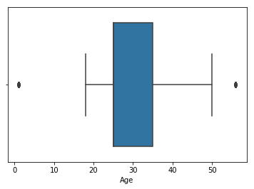

```python
# Lets try Box Plot for Age and see if there are outliers in the values
sns.boxplot(MasterDF["Age"])
plt.show()
# Below fig shows there are outliers in fig.
```

### Step3B : User rating of the movie “Toy Story”

```python
# User Rating for Movie Toy Story
Toy_Story_rating = pd.DataFrame(MasterDF[MasterDF["Movie_Name"] == 'Toy Story']["Rating"])
Toy_Story_rating.columns = ['Rating']
Toy_Story_rating.info()
Toy_Story_rating.Rating.value_counts()
```

```
<class 'pandas.core.frame.DataFrame'>
Int64Index: 2077 entries, 40 to 986829
Data columns (total 1 columns):
Rating    2077 non-null int64
dtypes: int64(1)
memory usage: 32.5 KB
```

```
4    835
5    820
3    345
2     61
1     16
Name: Rating, dtype: int64
```

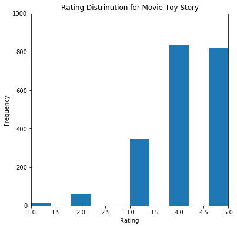

```python
# Lets Visualize the Rating for Movie Toy Story

plt.figure(figsize=(6,6))
plt.hist(Toy_Story_rating.Rating)
plt.xlim(1,5)
plt.ylim(0,1000)
plt.xlabel("Rating")
plt.ylabel("Frequency")
plt.title("Rating Distrinution for Movie Toy Story")
```

### STEP3C :Top 25 movies by viewership rating

```python
# Top 25 Movies by Rating
#MasterDF.sort_values(by=['Rating'],axis=1,ascending=False)
sorted_Master_DF = MasterDF.sort_values(by='Rating',ascending=False)
Top_25_movies = pd.DataFrame(sorted_Master_DF["Movie_Name"].unique()[0:25],columns=['Movie_Name'])
Top_25_movies
```

|  | Movie_Name |
| --- | --- |
| 0 | One Flew Over the Cuckoo's Nest |
| 1 | Crucible, The |
| 2 | Blow-Out (La Grande Bouffe) |
| 3 | Five Easy Pieces |
| 4 | Black Cauldron, The |
| 5 | Raging Bull |
| 6 | Cook the Thief His Wife & Her Lover, The |
| 7 | Great Escape, The |
| 8 | Conan the Barbarian |
| 9 | Sneakers |
| 10 | Devil's Advocate, The |
| 11 | Space Cowboys |
| 12 | Conquest of the Planet of the Apes |
| 13 | Secret of NIMH, The |
| 14 | Manhattan Murder Mystery |
| 15 | Love and Death |
| 16 | Mother |
| 17 | On Her Majesty's Secret Service |
| 18 | Fox and the Hound, The |
| 19 | Tron |
| 20 | Lolita |
| 21 | Jungle Fever |
| 22 | Blade Runner |
| 23 | Fantasia |
| 24 | Dr. Strangelove or: How I Learned to Stop Worr... |

### STEP3D : Find the ratings for all the movies reviewed by for a particular user of user id = 2696

```python
#Find the ratings for all the movies reviewed by for a particular user of user id = 2696
List_of_Movies_by_user_2696 = list(MasterDF[MasterDF.UserID == 2696]['Movie_Name'].unique())
print(List_of_Movies_by_user_2696)
np.count_nonzero(List_of_Movies_by_user_2696)
```

[output not shown]

```
20
```

```python
# Creating Small Dataframe Object to Store the information of Movies and Ratings Assigned by user '2696'
Movies_rated_by_2696 = pd.DataFrame(MasterDF[MasterDF.UserID == 2696]['Movie_Name'])
Movies_rated_by_2696.info()
```

```
<class 'pandas.core.frame.DataFrame'>
Int64Index: 20 entries, 953847 to 953866
Data columns (total 1 columns):
Movie_Name    20 non-null object
dtypes: object(1)
memory usage: 320.0+ bytes
```

```python
Movies_rated_by_2696['Rating'] = MasterDF[MasterDF.UserID == 2696]['Rating']
Movies_rated_by_2696.head(1)
```

|  | Movie_Name | Rating |
| --- | --- | --- |
| 953847 | Back to the Future | 2 |

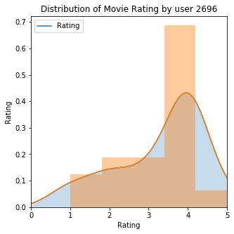

```python
# Plotting the Histogram to Visualize the rating of movies by the user id = 2696
plt.figure(figsize=(5,5))
sns.kdeplot(Movies_rated_by_2696.Rating,shade=True)
plt.xlim(0,5)
plt.xlabel("Frequency Count")
plt.ylabel("Rating")
plt.title("Distribution of Movie Rating by user 2696")
sns.distplot(Movies_rated_by_2696["Rating"])
```

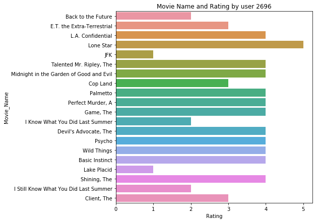

```python
# Bar Plot
plt.figure(figsize=(7,7))
plt.xlabel("Movie Names")
plt.ylabel("Rating")
plt.title("Movie Name and Rating by user 2696")
sns.barplot(y=Movies_rated_by_2696.Movie_Name,x=Movies_rated_by_2696.Rating,orient="V")
```

## PART 2: Feature Engineering

```python
MasterDF.info()
```

```
<class 'pandas.core.frame.DataFrame'>
Int64Index: 1000209 entries, 0 to 1000208
Data columns (total 13 columns):
UserID          1000209 non-null int64
MovieID         1000209 non-null int64
Rating          1000209 non-null int64
Title           1000209 non-null object
Genres          1000209 non-null object
Gender          1000209 non-null object
Age             1000209 non-null int64
Occupation      1000209 non-null int64
Zip-code        1000209 non-null object
Date            1000209 non-null object
Time            1000209 non-null object
Release_year    1000209 non-null int32
Movie_Name      1000209 non-null object
dtypes: int32(1), int64(5), object(7)
memory usage: 103.0+ MB
```

### Converting Gender column into one Hot encoded values.

```python
# Gender column conversion
MasterDF.Gender.replace(['M','F'],[1,0],inplace=True)
```

### Handling the Release column to extract features as Release Decade

```python
# lets find out Range of release years of Movie Data
print(MasterDF.Release_year.min())
print(MasterDF.Release_year.max())

#print(bins)
#============================================================================
# 1930s : Movie release year <= 1930
# 1940s : Movie release year <= 1940 and > 1930
# 1950s : Movie release year <= 1950 and > 1940
# 1960s : Movie release year <= 1960 and > 1950
# 1970s : Movie release year <= 1970 and > 1960
# 1980s : Movie release year <= 1980 and > 1970
# 1990s : Movie release year <= 1990 and > 1980
# 2000s : Movie release year <= 2000 and > 1990
#============================================================================
cut_bins = [1915,1930,1940,1950,1960,1970,1980,1990,2000]
cut_labels = ['1930s','1940s','1950s','1960s','1970s','1980s','1990s','2000s']
MasterDF["Release_Decade"] = pd.cut(MasterDF.Release_year,bins=cut_bins,labels=cut_labels)

# Now Replace using numeric Values
MasterDF.Release_Decade.replace(['1930s','1940s','1950s','1960s','1970s','1980s','1990s','2000s'],
                                                          [1,2,3,4,5,6,7,8],inplace=True)

# Here we have convered the Year release into a Release_decade column
```

```
1919
2000
```

### Extracting Features as 'Year of Rating' and 'Month of Rating' based Date

```python
MasterDF["Year_of_Rating"]=pd.DatetimeIndex(MasterDF["Date"]).year
MasterDF["Month_of_Rating"]=pd.DatetimeIndex(MasterDF["Date"]).month
```

```python
MasterDF.info()
```

```
<class 'pandas.core.frame.DataFrame'>
Int64Index: 1000209 entries, 0 to 1000208
Data columns (total 16 columns):
UserID             1000209 non-null int64
MovieID            1000209 non-null int64
Rating             1000209 non-null int64
Title              1000209 non-null object
Genres             1000209 non-null object
Gender             1000209 non-null int64
Age                1000209 non-null int64
Occupation         1000209 non-null int64
Zip-code           1000209 non-null object
Date               1000209 non-null object
Time               1000209 non-null object
Release_year       1000209 non-null int32
Movie_Name         1000209 non-null object
Release_Decade     1000209 non-null int64
Year_of_Rating     1000209 non-null int64
Month_of_Rating    1000209 non-null int64
dtypes: int32(1), int64(9), object(6)
memory usage: 125.9+ MB
```

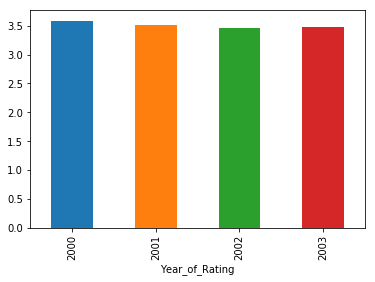

```python
# Rating Vs Gender Visualizations
MasterDF.groupby("Year_of_Rating")["Rating"].mean().plot(kind="bar")
# This shows that Average Rating is not affected that much by year of rating.
```

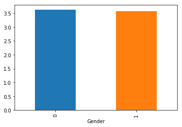

```python
# Gender vs Rating
MasterDF.groupby("Gender")["Rating"].mean().plot(kind="bar")
# This shows that the average rating is not affected that much by Gender
```

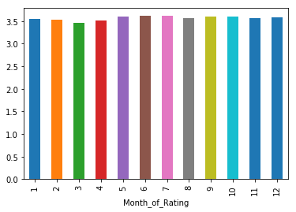

```python
# Month of Rating Vs Rating
MasterDF.groupby("Month_of_Rating")["Rating"].mean().plot(kind="bar")
# This shows that there is no variance in average rating based on Month of Rating
```

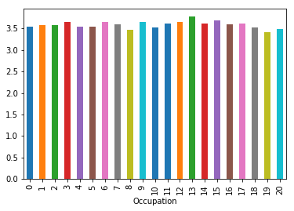

```python
# Rating Vs Occupation
MasterDF.groupby("Occupation")["Rating"].mean().plot(kind="bar")
# Below graph shows us that Average rating varies a bit with Occupration
```

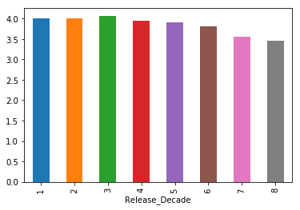

```python
# Decade of release vs Rating
MasterDF.groupby("Release_Decade")["Rating"].mean().plot(kind="bar")
# Below graph shows us that the Rating is affected by release year
```

### STEP4A: Create a separate column for each genre category with a one-hot encoding

```python
#Let handle the Generes Column
TestDF = MasterDF
Genere_DF = TestDF.Genres.str.get_dummies()
Final_DF = pd.concat([MasterDF,Genere_DF],axis=1)
```

```python
# Drop all non Important columns from Dataframe
Final_DF.drop(columns=['Genres','Zip-code','Date','Time','Release_year'],axis=1,inplace=True)
```

```python
Final_DF.info()
```

```
<class 'pandas.core.frame.DataFrame'>
Int64Index: 1000209 entries, 0 to 1000208
Data columns (total 29 columns):
UserID             1000209 non-null int64
MovieID            1000209 non-null int64
Rating             1000209 non-null int64
Title              1000209 non-null object
Gender             1000209 non-null int64
Age                1000209 non-null int64
Occupation         1000209 non-null int64
Movie_Name         1000209 non-null object
Release_Decade     1000209 non-null int64
Year_of_Rating     1000209 non-null int64
Month_of_Rating    1000209 non-null int64
Action             1000209 non-null int64
Adventure          1000209 non-null int64
Animation          1000209 non-null int64
Children's         1000209 non-null int64
Comedy             1000209 non-null int64
Crime              1000209 non-null int64
Documentary        1000209 non-null int64
Drama              1000209 non-null int64
Fantasy            1000209 non-null int64
Film-Noir          1000209 non-null int64
Horror             1000209 non-null int64
Musical            1000209 non-null int64
Mystery            1000209 non-null int64
Romance            1000209 non-null int64
Sci-Fi             1000209 non-null int64
Thriller           1000209 non-null int64
War                1000209 non-null int64
Western            1000209 non-null int64
dtypes: int64(27), object(2)
memory usage: 228.9+ MB
```

### Correlation Analysis between Features and Target Variables

```python
pd.set_option('display.precision',3)
```

```python
Final_DF.corr().round(3)
```

|  | UserID | MovieID | Rating | Gender | Age | Occupation | Release_Decade | Year_of_Rating | Month_of_Rating | Action | ... | Fantasy | Film-Noir | Horror | Musical | Mystery | Romance | Sci-Fi | Thriller | War | Western |
| --- | --- | --- | --- | --- | --- | --- | --- | --- | --- | --- | --- | --- | --- | --- | --- | --- | --- | --- | --- | --- | --- |
| UserID | 1.000 | -0.018 | 0.012 | -0.035 | 0.035 | -0.027 | -0.028 | -0.094 | -0.634 | -0.002 | ... | 0.002 | 0.005 | -0.001 | -0.000 | 0.004 | 0.007 | -0.003 | -0.001 | 0.004 | 0.004 |
| MovieID | -0.018 | 1.000 | -0.064 | 0.022 | 0.028 | 0.009 | -0.072 | 0.039 | -0.003 | -0.042 | ... | -0.019 | -0.020 | 0.058 | -0.059 | -0.029 | -0.118 | -0.012 | -0.058 | -0.082 | 0.004 |
| Rating | 0.012 | -0.064 | 1.000 | -0.020 | 0.057 | 0.007 | -0.153 | -0.025 | 0.001 | -0.048 | ... | -0.023 | 0.060 | -0.094 | 0.016 | 0.016 | 0.010 | -0.044 | -0.005 | 0.076 | 0.007 |
| Gender | -0.035 | 0.022 | -0.020 | 1.000 | -0.003 | 0.115 | -0.003 | -0.027 | 0.036 | 0.094 | ... | 0.003 | 0.005 | 0.037 | -0.038 | -0.001 | -0.091 | 0.072 | 0.038 | 0.026 | 0.026 |
| Age | 0.035 | 0.028 | 0.057 | -0.003 | 1.000 | 0.078 | -0.161 | -0.066 | 0.016 | -0.031 | ... | -0.024 | 0.033 | -0.024 | 0.005 | 0.024 | 0.018 | -0.011 | -0.014 | 0.038 | 0.038 |
| Occupation | -0.027 | 0.009 | 0.007 | 0.115 | 0.078 | 1.000 | -0.010 | -0.003 | 0.035 | 0.018 | ... | 0.001 | 0.005 | 0.001 | -0.007 | 0.002 | -0.014 | 0.026 | 0.009 | 0.010 | 0.006 |
| Release_Decade | -0.028 | -0.072 | -0.153 | -0.003 | -0.161 | -0.010 | 1.000 | 0.013 | 0.010 | 0.091 | ... | -0.004 | -0.130 | -0.066 | -0.207 | -0.042 | 0.034 | 0.005 | 0.091 | -0.106 | -0.075 |
| Year_of_Rating | -0.094 | 0.039 | -0.025 | -0.027 | -0.066 | -0.003 | 0.013 | 1.000 | -0.433 | -0.040 | ... | -0.011 | -0.009 | -0.009 | 0.001 | -0.006 | -0.002 | -0.031 | -0.013 | -0.018 | -0.006 |
| Month_of_Rating | -0.634 | -0.003 | 0.001 | 0.036 | 0.016 | 0.035 | 0.010 | -0.433 | 1.000 | 0.018 | ... | 0.001 | 0.001 | 0.005 | -0.001 | -0.001 | -0.004 | 0.017 | 0.003 | 0.010 | 0.001 |
| Action | -0.002 | -0.042 | -0.048 | 0.094 | -0.031 | 0.018 | 0.091 | -0.040 | 0.018 | 1.000 | ... | 0.015 | -0.080 | -0.043 | -0.100 | -0.054 | -0.068 | 0.319 | 0.203 | 0.136 | 0.022 |
| Adventure | -0.001 | -0.082 | -0.037 | 0.039 | -0.017 | 0.014 | -0.019 | -0.027 | 0.011 | 0.375 | ... | 0.227 | -0.014 | -0.057 | -0.022 | -0.044 | -0.024 | 0.284 | -0.038 | 0.017 | -0.012 |
| Animation | -0.008 | -0.014 | 0.020 | -0.018 | -0.047 | -0.004 | -0.048 | 0.000 | 0.000 | -0.110 | ... | 0.012 | 0.037 | -0.050 | 0.335 | -0.042 | -0.055 | -0.056 | -0.086 | -0.046 | -0.031 |
| Children's | -0.005 | -0.072 | -0.040 | -0.032 | -0.053 | -0.007 | -0.075 | -0.000 | -0.002 | -0.141 | ... | 0.263 | -0.038 | -0.077 | 0.313 | -0.053 | -0.085 | -0.039 | -0.133 | -0.067 | -0.031 |
| Comedy | -0.004 | 0.062 | -0.040 | -0.041 | -0.044 | -0.006 | 0.098 | 0.006 | -0.001 | -0.268 | ... | -0.006 | -0.101 | -0.093 | 0.031 | -0.105 | 0.113 | -0.187 | -0.300 | -0.127 | 0.008 |
| Crime | 0.003 | -0.062 | 0.033 | 0.027 | -0.008 | 0.003 | 0.056 | -0.009 | -0.000 | 0.089 | ... | -0.034 | 0.136 | -0.048 | -0.061 | 0.080 | -0.073 | -0.084 | 0.115 | -0.080 | -0.043 |
| Documentary | -0.001 | -0.010 | 0.028 | 0.000 | 0.004 | -0.003 | 0.040 | 0.009 | -0.002 | -0.053 | ... | -0.017 | -0.012 | -0.026 | -0.007 | -0.018 | -0.037 | -0.039 | -0.043 | -0.016 | -0.013 |
| Drama | 0.007 | -0.031 | 0.123 | -0.052 | 0.064 | -0.012 | 0.021 | 0.013 | -0.007 | -0.202 | ... | -0.097 | -0.067 | -0.190 | -0.095 | -0.028 | 0.024 | -0.213 | -0.154 | 0.137 | -0.046 |
| Fantasy | 0.002 | -0.019 | -0.023 | 0.003 | -0.024 | 0.001 | -0.004 | -0.011 | 0.001 | 0.015 | ... | 1.000 | -0.026 | -0.056 | -0.020 | -0.040 | -0.015 | 0.122 | -0.087 | -0.045 | -0.028 |
| Film-Noir | 0.005 | -0.020 | 0.060 | 0.005 | 0.033 | 0.005 | -0.130 | -0.009 | 0.001 | -0.080 | ... | -0.026 | 1.000 | -0.039 | -0.028 | 0.215 | -0.047 | -0.004 | 0.115 | -0.037 | -0.020 |
| Horror | -0.001 | 0.058 | -0.094 | 0.037 | -0.024 | 0.001 | -0.066 | -0.009 | 0.005 | -0.043 | ... | -0.056 | -0.039 | 1.000 | -0.019 | -0.002 | -0.099 | 0.057 | 0.057 | -0.078 | -0.042 |
| Musical | -0.000 | -0.059 | 0.016 | -0.038 | 0.005 | -0.007 | -0.207 | 0.001 | -0.001 | -0.100 | ... | -0.020 | -0.028 | -0.019 | 1.000 | -0.043 | 0.024 | -0.068 | -0.101 | -0.034 | -0.030 |
| Mystery | 0.004 | -0.029 | 0.016 | -0.001 | 0.024 | 0.002 | -0.042 | -0.006 | -0.001 | -0.054 | ... | -0.040 | 0.215 | -0.002 | -0.043 | 1.000 | -0.040 | -0.028 | 0.225 | -0.055 | -0.030 |
| Romance | 0.007 | -0.118 | 0.010 | -0.091 | 0.018 | -0.014 | 0.034 | -0.002 | -0.004 | -0.068 | ... | -0.015 | -0.047 | -0.099 | 0.024 | -0.040 | 1.000 | -0.134 | -0.081 | 0.053 | -0.045 |
| Sci-Fi | -0.003 | -0.012 | -0.044 | 0.072 | -0.011 | 0.026 | 0.005 | -0.031 | 0.017 | 0.319 | ... | 0.122 | -0.004 | 0.057 | -0.068 | -0.028 | -0.134 | 1.000 | 0.103 | 0.039 | -0.011 |
| Thriller | -0.001 | -0.058 | -0.005 | 0.038 | -0.014 | 0.009 | 0.091 | -0.013 | 0.003 | 0.203 | ... | -0.087 | 0.115 | 0.057 | -0.101 | 0.225 | -0.081 | 0.103 | 1.000 | -0.088 | -0.059 |
| War | 0.004 | -0.082 | 0.076 | 0.026 | 0.038 | 0.010 | -0.106 | -0.018 | 0.010 | 0.136 | ... | -0.045 | -0.037 | -0.078 | -0.034 | -0.055 | 0.053 | 0.039 | -0.088 | 1.000 | -0.020 |
| Western | 0.004 | 0.004 | 0.007 | 0.026 | 0.038 | 0.006 | -0.075 | -0.006 | 0.001 | 0.022 | ... | -0.028 | -0.020 | -0.042 | -0.030 | -0.030 | -0.045 | -0.011 | -0.059 | -0.020 | 1.000 |

27 rows × 27 columns

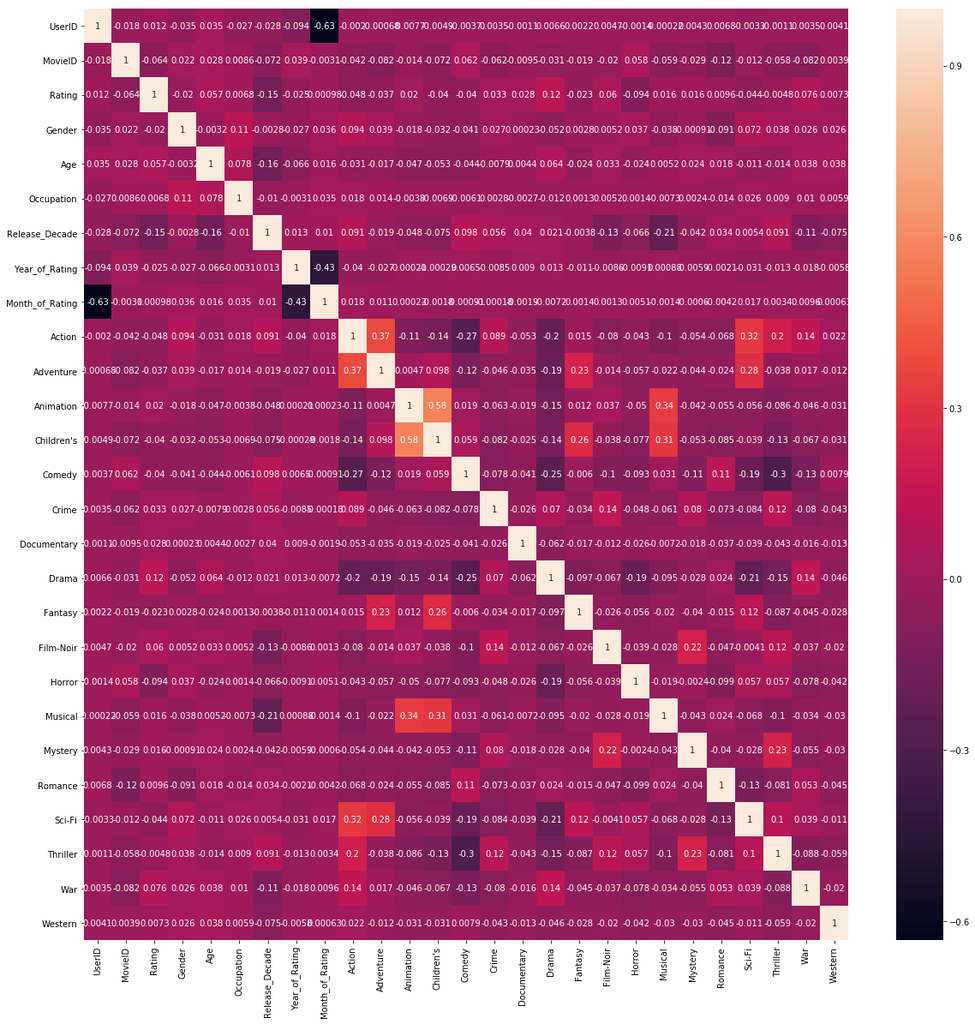

```python
plt.figure(figsize=(20,20))
sns.heatmap(Final_DF.corr(),annot=True)
```

```python
#Correlation with output variable
cor=Final_DF.corr().round(2)
cor_target = abs(cor["Rating"])
#Selecting highly correlated features
relevant_features = cor_target[cor_target>0.05]
list1=[]
list1=relevant_features.index
print(list1)
print(cor_target)
```

```
Index(['MovieID', 'Rating', 'Age', 'Release_Decade', 'Drama', 'Film-Noir',
       'Horror', 'War'],
      dtype='object')
UserID             0.01
MovieID            0.06
Rating             1.00
Gender             0.02
Age                0.06
Occupation         0.01
Release_Decade     0.15
Year_of_Rating     0.02
Month_of_Rating    0.00
Action             0.05
Adventure          0.04
Animation          0.02
Children's         0.04
Comedy             0.04
Crime              0.03
Documentary        0.03
Drama              0.12
Fantasy            0.02
Film-Noir          0.06
Horror             0.09
Musical            0.02
Mystery            0.02
Romance            0.01
Sci-Fi             0.04
Thriller           0.00
War                0.08
Western            0.01
Name: Rating, dtype: float64
```

```python
list1[2::]
```

```
Index(['Age', 'Release_Decade', 'Drama', 'Film-Noir', 'Horror', 'War'], dtype='object')
```

```python
FeaturesDF= Final_DF[list1]
```

```python
FeaturesDF.head(1)
```

|  | MovieID | Rating | Age | Release_Decade | Drama | Film-Noir | Horror | War |
| --- | --- | --- | --- | --- | --- | --- | --- | --- |
| 0 | 1193 | 5 | 1 | 6 | 1 | 0 | 0 | 0 |

```python
label = np.array(FeaturesDF.Rating)
Features = np.array(FeaturesDF.iloc[:,2::])
#label.shape
#Features.shap
Features[0::]
```

```
array([[ 1,  6,  1,  0,  0,  0],
       [ 1,  8,  0,  0,  0,  0],
       [ 1,  5,  0,  0,  0,  0],
       ...,
       [45,  7,  0,  0,  1,  0],
       [45,  7,  0,  0,  0,  1],
       [45,  6,  1,  0,  0,  0]], dtype=int64)
```

### Building Appropriate Model to predict the movie rating.

```python
# Logistic Regression.
Highest_test_Score = 0
Best_Random_state  = 0
for i in range(1,10):

    from sklearn.model_selection import train_test_split
    from sklearn.linear_model import LogisticRegression

    x_train,x_test,y_train,y_test = train_test_split(Features,label,test_size=0.25,random_state=i)
    model = LogisticRegression()
    model.fit(x_train,y_train)
    LogRegTrainScore=model.score(x_train,y_train)
    LogRegTestScore=model.score(x_test,y_test)
    if LogRegTestScore > LogRegTrainScore:
            print("Training Score is :{} and testing score is :{} for Random state:{}".
            format(LogRegTrainScore,LogRegTestScore,i))
            if Highest_test_Score < LogRegTestScore:
                Highest_test_Score = LogRegTestScore
                Best_Random_state = i

print('Highest_test_Score: {} is for Random State : {}'.format(Highest_test_Score,Best_Random_state))
```

```
Training Score is :0.3521014295693162 and testing score is :0.3522013333173367 for Random state:3
Training Score is :0.3519934520286447 and testing score is :0.3522013333173367 for Random state:4
Training Score is :0.3518641455910504 and testing score is :0.3521013545128433 for Random state:6
Training Score is :0.3520147809255675 and testing score is :0.35238129516542493 for Random state:8
Highest_test_Score: 0.35238129516542493 is for Random State : 8
```

```python
# Descion Tress
DT_Best_Accuracy_score = 0
DT_best_random_state = 0
from sklearn.tree import DecisionTreeClassifier
from sklearn.model_selection import train_test_split
for i in range(1,50):
    x_train,x_test,y_train,y_test = train_test_split(Features,label,test_size=0.25,random_state=i)
    DTModel = DecisionTreeClassifier()
    DTModel.fit(x_train,y_train)
    DTTestScore  = DTModel.score(x_train,y_train)
    DTTrainScore = DTModel.score(x_test,y_test)
    if DTTestScore > DTTrainScore:
        if DT_Best_Accuracy_score < DTTestScore:
            DT_Best_Accuracy_score = DTTestScore
            DT_best_random_state = i


print('Best Test Score {} is for Random State {} with Train score of {}'.
      format(DT_Best_Accuracy_score,DT_best_random_state,DTTrainScore))
```

```
Best Test Score 0.3560152821546452 is for Random State 31 with Train score of 0.35340907727561754
```

```python
# Neive Bayes

NB_Best_Acc_score = 0
NB_Best_random_state = 0

from sklearn.naive_bayes import BernoulliNB
from sklearn.model_selection import train_test_split

for i in range(1,50):
    x_train,x_test,y_train,y_test = train_test_split(Features,label,test_size=0.25,random_state=i)
    NB_model = BernoulliNB()
    NB_model.fit(x_train,y_train)
    NBTestScore = NB_model.score(x_test,y_test)
    NBTrainScore = NB_model.score(x_train,y_train)

    if NBTestScore > NBTrainScore:
        if NBTestScore > NB_Best_Acc_score:
            NB_Best_Acc_score = NBTestScore
            NB_Best_random_state = i

print('Best Test Score : {} is for Random State :{} with train score :{}'.
      format(NB_Best_Acc_score,NB_Best_random_state,NBTrainScore))
```

```
Best Test Score : 0.35082162581532716 is for Random State :14 with train score :0.34888209919003516
```

```python
# Random Forest
RF_Best_Acc_score = 0
RF_Best_random_state = 0

from sklearn.ensemble import RandomForestClassifier
from sklearn.model_selection import train_test_split

for i in range(1,50):
    x_train,x_test,y_train,y_test = train_test_split(Features,label,test_size=0.25,random_state=i)
    RF_model = RandomForestClassifier()
    RF_model.fit(x_train,y_train)
    RFTestScore = RF_model.score(x_test,y_test)
    RFTrainScore = RF_model.score(x_train,y_train)

    if RFTestScore > RFTrainScore:
        if RFTestScore > RF_Best_Acc_score:
            RF_Best_Acc_score = RFTestScore
            RF_Best_random_state = i

print('Best Test Score : {} is for Random State :{} with train score :{}'.
      format(RF_Best_Acc_score,RF_Best_random_state,RFTrainScore))
```

```
Best Test Score : 0.35601652449680665 is for Random State :17 with train score :0.3554540655543647
```

```python
# One Vs Rest Classifier
OVR_Best_Score = 0
OVR_Best_Random_State = 0

from sklearn.linear_model import LogisticRegression
from sklearn.model_selection import train_test_split

for i in range(1,50):
    x_train,x_test,y_train,y_test = train_test_split(Features,label,test_size=0.25,random_state=i)
    OVR_Model = LogisticRegression(multi_class='ovr')
    OVR_Model.fit(x_train,y_train)
    OVRTestScore  = OVR_Model.score(x_test,y_test)
    OVRTrainScore = OVR_Model.score(x_train,y_train)
    if OVRTestScore > OVRTrainScore:
        if OVR_Best_Score < OVRTestScore:
            OVR_Best_Score = OVRTrainScore

print('Best Test Score : {} is for Random State :{} with train score :{}'.
      format(OVR_Best_Score,OVR_Best_Random_State,OVRTrainScore))
```

```
Best Test Score : 0.3521240915222967 is for Random State :0 with train score :0.35242136302315785
```

```python
# Store the results from each model into Seperate Dataframe
List_of_col = ['Model_Name','Model_Best_Scores']
Results = pd.DataFrame(columns=List_of_col)

Model_list = ['Logistic_reg','Descion Trees','Neive Bayes','Random Forest','One Vs Rest LogReg']
Score_list = [Highest_test_Score,DT_Best_Accuracy_score,NB_Best_Acc_score,RF_Best_Acc_score,OVR_Best_Score]
Results['Model_Name'] = Model_list
Results['Model_Best_Scores'] = Score_list
```

```python
# Accuracy Scores of All the Confusion Matrix for all Models.
Results
```

|  | Model_Name | Model_Best_Scores |
| --- | --- | --- |
| 0 | Logistic_reg | 0.352 |
| 1 | Descion Trees | 0.356 |
| 2 | Neive Bayes | 0.351 |
| 3 | Random Forest | 0.356 |
| 4 | One Vs Rest LogReg | 0.352 |

```python
# Lets check weather the Dataset is Balanced or Not
Final_DF.Rating.value_counts()
# Below Results show that there is diversity in Ratings and its a Unbalanced Dataset.
```

```
4    348971
3    261197
5    226310
2    107557
1     56174
Name: Rating, dtype: int64
```

```python
# Calculating Accuracies of Different Models

from sklearn.metrics import accuracy_score
from sklearn.metrics import confusion_matrix
from sklearn.metrics import classification_report

# 1. Accuracy Score of Logistic Regression
print(accuracy_score(label,model.predict(Features)))
# 2. Accuracy Score of Descion Trees
print(accuracy_score(label,DTModel.predict(Features)))
# 3. Accuracy Score of Neive Bayes
print(accuracy_score(label,NB_model.predict(Features)))
# 4. Accuracy Score of Random Forest
print(accuracy_score(label,RF_model.predict(Features)))
# 5. Accuracy Score of One Vs Rest LogReg
print(accuracy_score(label,OVR_Model.predict(Features)))

Results["Accuracy Score"] = [accuracy_score(label,model.predict(Features)),
                            accuracy_score(label,DTModel.predict(Features)),
                            accuracy_score(label,NB_model.predict(Features)),
                            accuracy_score(label,RF_model.predict(Features)),
                            accuracy_score(label,OVR_Model.predict(Features))]
```

```
0.3521653974319367
0.35499480608552814
0.3487281158237928
0.35489382719011725
0.3521484009841943
```

### Confusion Matrix and Classification Reports for All Models

```python
# Confusion Matrix and Classification Reports

#1. Logistic Regression
print("Logistic Regression")
Logcm = confusion_matrix(label,model.predict(Features))
print(Logcm)
Log_classification_report = classification_report(label,model.predict(Features))
print(Log_classification_report)
```

```
Logistic Regression
[[     0      0   7029  48445    700]
 [     0      0   8990  97021   1546]
 [     0      0  14522 239343   7332]
 [     0      0  13229 319140  16602]
 [     0      0   5431 202302  18577]]
              precision    recall  f1-score   support

           1       0.00      0.00      0.00     56174
           2       0.00      0.00      0.00    107557
           3       0.30      0.06      0.09    261197
           4       0.35      0.91      0.51    348971
           5       0.42      0.08      0.14    226310

   micro avg       0.35      0.35      0.35   1000209
   macro avg       0.21      0.21      0.15   1000209
weighted avg       0.29      0.35      0.23   1000209
```

```python
#2. Descion Tress.
DTcm = confusion_matrix(label,DTModel.predict(Features))
print(DTcm)
DT_classification_report = classification_report(label,DTModel.predict(Features))
print(DT_classification_report)
```

```
[[     7      8   6527  48567   1065]
 [     4     12   8884  96371   2286]
 [     7     10  14632 237204   9344]
 [     1      6  13046 316285  19633]
 [     2      3   5361 196811  24133]]
              precision    recall  f1-score   support

           1       0.33      0.00      0.00     56174
           2       0.31      0.00      0.00    107557
           3       0.30      0.06      0.09    261197
           4       0.35      0.91      0.51    348971
           5       0.43      0.11      0.17    226310

   micro avg       0.35      0.35      0.35   1000209
   macro avg       0.34      0.21      0.15   1000209
weighted avg       0.35      0.35      0.24   1000209
```

```python
#3. Neive Bayes

NBcm = confusion_matrix(label,NB_model.predict(Features))
print(NBcm)
NB_classification_report = classification_report(label,NB_model.predict(Features))
print(NB_classification_report)
```

```
[[     0      0   8661  46582    931]
 [     0      0  11464  93824   2269]
 [     0      0  20426 232830   7941]
 [     0      0  21053 312237  15681]
 [     0      0  11791 198381  16138]]
              precision    recall  f1-score   support

           1       0.00      0.00      0.00     56174
           2       0.00      0.00      0.00    107557
           3       0.28      0.08      0.12    261197
           4       0.35      0.89      0.51    348971
           5       0.38      0.07      0.12    226310

   micro avg       0.35      0.35      0.35   1000209
   macro avg       0.20      0.21      0.15   1000209
weighted avg       0.28      0.35      0.24   1000209
```

```python
#4. Random Forest

RFcm = confusion_matrix(label,RF_model.predict(Features))
print(RFcm)
RF_classification_report = classification_report(label,RF_model.predict(Features))
print(RF_classification_report)
```

```
[[     4      8   6550  48396   1216]
 [     3     14   8893  96100   2547]
 [     3     13  14678 236509   9994]
 [     0      6  13131 315014  20820]
 [     2      3   5444 195603  25258]]
              precision    recall  f1-score   support

           1       0.33      0.00      0.00     56174
           2       0.32      0.00      0.00    107557
           3       0.30      0.06      0.09    261197
           4       0.35      0.90      0.51    348971
           5       0.42      0.11      0.18    226310

   micro avg       0.35      0.35      0.35   1000209
   macro avg       0.35      0.21      0.16   1000209
weighted avg       0.35      0.35      0.24   1000209
```

```python
#5. One Vs Rest LogReg

OVRcm = confusion_matrix(label,OVR_Model.predict(Features))
print(OVRcm)
OVR_classification_report = classification_report(label,OVR_Model.predict(Features))
print(OVR_classification_report)
```

```
[[     0      0   6531  48934    709]
 [     0      0   8529  97462   1566]
 [     0      0  13676 240104   7417]
 [     0      0  12409 319816  16746]
 [     0      0   5083 202497  18730]]
              precision    recall  f1-score   support

           1       0.00      0.00      0.00     56174
           2       0.00      0.00      0.00    107557
           3       0.30      0.05      0.09    261197
           4       0.35      0.92      0.51    348971
           5       0.41      0.08      0.14    226310

   micro avg       0.35      0.35      0.35   1000209
   macro avg       0.21      0.21      0.15   1000209
weighted avg       0.29      0.35      0.23   1000209
```